# ECON6635 Final Exam Spring 2024

Dr. Esin Cakan

Group no 14

2024-05-04

The Final Exam is out of 35 points. Please see all 3 questions given below.

Question #1 and #2 are 15 points. Question #3 is 5 points. Each question will be graded as given in the rubrics on syllabus. You should knit this file with your name written in “author” section at top; and knit as html file. Submit the html file as your Exam. Do not submit pdf or word file. No points will be assigned if it is not in html format or it is submitted late. It should be your own work.

Please answer each question in the given space. The codes in one R-chunk for each question. Make sure it is running. Make sure your data is also readable if you import Excel data (you can post it on Google Doc and give a link, for example). I could be able to run your codes on my machine, if needed. In each question, Part a is for your codes; and Part b is for summary of what you found out in your codes. It should show your ability to comment on result of codes and make your audience to understand about your findings technically and non-technically.

```r
# Do NOT use forecast package. You should use fpp3 package only.
# install below packages first:

library(fpp3)
library(tidyverse)
library(TSstudio) # install first.
```

```r
library(dygraphs)
library(pacman)
        pacman::p_load(forecast)
        p_load(tidyverse, lubridate, rio, pdfetch, tidyverse, readxl)
        library(dygraphs)
Sys.time()
```

```
## [1] "2024-05-04 15:35:13 EDT"
```

## 1.

- Select a “monthly” time series from Quandl or FRED by yourself. it should be specific to you only. (If it is not monthly, make it monthly series, by using collapse() command).
- Transform the data into monthly tsibble format. Make sure the series is tsibble to be able to use many fpp3 package commands to forecast with graphs.
- After plotting graph of the series, comment on the graph. Explain what you determine visually.
- Then divide the series into two parts as training and test data set (you can use subset() or window()command for dividing data into training and test). You decide how many observations you need to leave as test data set (e.g. 80% of test, 20% training data set).
- Identify an appropriate ARIMA model for the training data. You should do residual diagnostics of your ARIMA model to make sure the residuals are white noise. If needed, take logarithms of the series, or make any needed transformation. It is your call!
- Then explain which ARIMA model you would chose. Use your chosen ARIMA model to forecast for whole data set. Calculate the accuracy of the forecasted model. what you get as RMSE? Explain what RMSE means.
- Plot the ARIMA model with forecasted value and test data value together. What do you see visually? (e.g. you can use autoplot() and autolayer() commands)
- Check the accuracy of the test data series.
- Identify an ETS for the training data set. Then use the model to forecast for the whole data set. Calculate the accuracy of the model for the test data set. Compare the accuracy values from ETS model with ARIMA model. Comment on which model is better to use for ahead forecasting. Which one would you choose? Explain briefly why and how did you come on that conclusion.
- By using the model you chose, forecast for next 1 year ahead. What would be the first month forecasted value ahead? Plot the 1 year ahead forecasted values with the original data set in a graph, give with a confidence interval for forecasted values.

```r
library(fpp3)
library(tsibble)
library(forecast)
library(pdfetch)
library(Quandl)
library(quantmod)
```

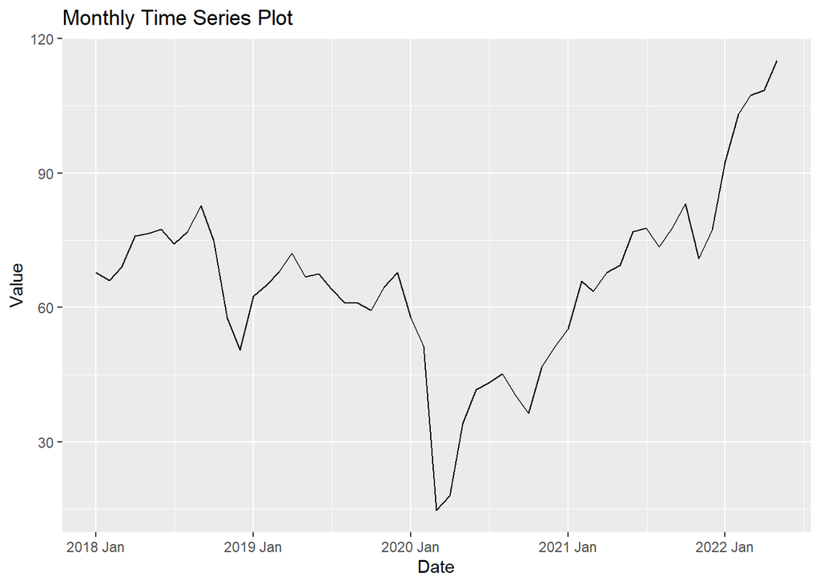

```r
Quandl.api_key("zLkjeScazmAJP5Z59-wF")
data <- Quandl("FRED/DCOILBRENTEU", collapse = "monthly")


data_tsibble <- data %>%
  mutate(Date = as.Date(Date),
         MONTH = yearmonth(Date)) %>%
  as_tsibble(index = MONTH) %>%
  filter(year(MONTH) >= 2018, year(MONTH) <= 2022)

# Plot the time series
autoplot(data_tsibble, Value) +
  ggtitle("Monthly Time Series Plot") +
  xlab("Date") +
  ylab("Value")
```

```r
# Divide the series into training and testing datasets
set.seed(123) # for reproducibility
train_size <- floor(0.7 * nrow(data_tsibble))

# Split the data into training and testing sets
train_data <- data_tsibble[1:train_size, ]
test_data <- data_tsibble[(train_size + 1):nrow(data_tsibble), ]

# Fit an ARIMA model on the training data
arima_fit <- train_data %>%
  model(ARIMA(Value))

arima_fit %>%
  report()
```

```
## Series: Value
## Model: ARIMA(0,1,0)
##
## sigma^2 estimated as 77.01:  log likelihood=-129.27
## AIC=260.55   AICc=260.66   BIC=262.13
```

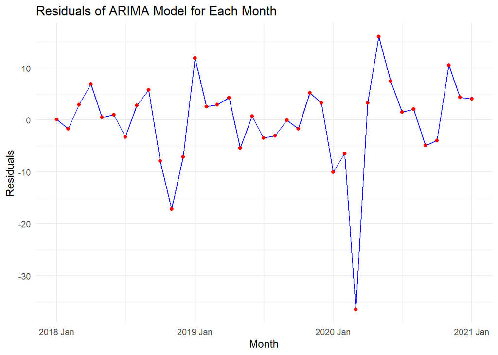

```r
residual_data <- residuals(arima_fit)
ggplot(residual_data, aes(x = MONTH, y = .resid)) +
geom_line(group=1, colour="blue") +  # Line plot of the residuals
geom_point(colour="red") +  # Add points for clarity
labs(title = "Residuals of ARIMA Model for Each Month", x = "Month", y = "Residuals") +
theme_minimal()
```

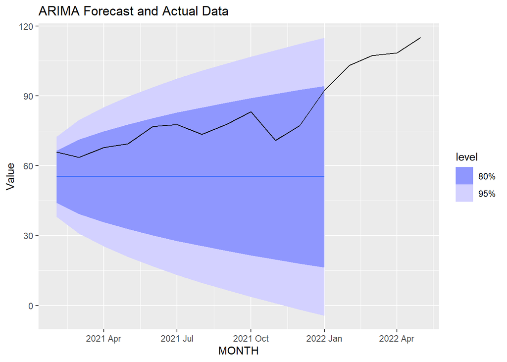

```r
# Forecast using the ARIMA model
arima_forecast <- forecast(arima_fit, h = "1 year")
autoplot(arima_forecast) +
  ggtitle("ARIMA Forecast and Actual Data") +
  autolayer(test_data, Value, series = "Test Data")
```

```r
# Calculate the accuracy of the forecasted model, specifically RMSE
arima_accuracy <- accuracy(arima_forecast, test_data)
cat("ARIMA Model RMSE:", arima_accuracy$RMSE, "\n")
```

```
## ARIMA Model RMSE: 20.87786
```

```r
# Fit an ETS model on the training data
ets_fit <- train_data %>%
  model(ETS(Value))

ets_fit %>%
  report()
```

```
## Series: Value
## Model: ETS(A,N,N)
##   Smoothing parameters:
##     alpha = 0.9998997
##
##   Initial states:
##      l[0]
##  67.76487
##
##   sigma^2:  79.2132
##
##      AIC     AICc      BIC
## 299.3172 300.0444 304.1499
```

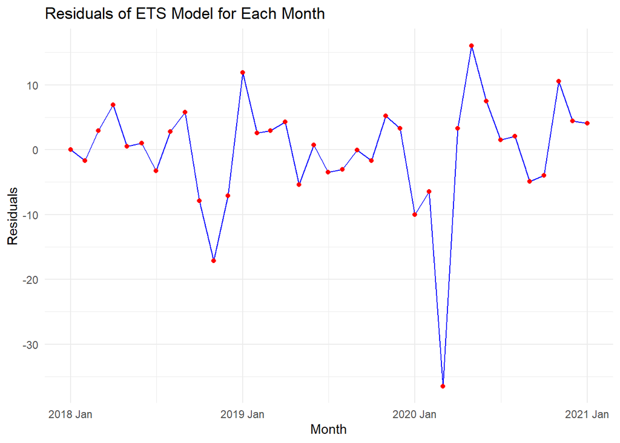

```r
residual_data <- residuals(ets_fit)
ggplot(residual_data, aes(x = MONTH, y = .resid)) +
geom_line(group=1, colour="blue") +  # Line plot of the residuals
geom_point(colour="red") +  # Add points for clarity
labs(title = "Residuals of ETS Model for Each Month", x = "Month", y = "Residuals") +
theme_minimal()
```

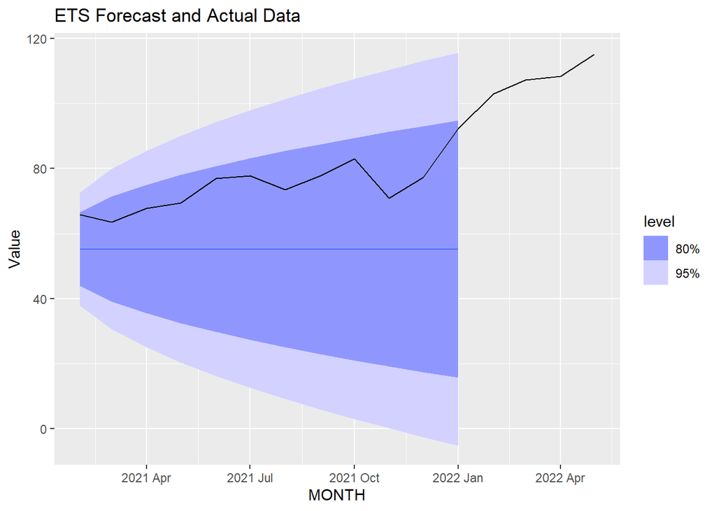

```r
# Forecast using the ETS model
ets_forecast <- forecast(ets_fit, h = "1 year")
autoplot(ets_forecast) +
  ggtitle("ETS Forecast and Actual Data") +
  autolayer(test_data, Value, series = "Test Data")
```

```r
# Compare the accuracy values from ARIMA and ETS models
ets_accuracy <- accuracy(ets_forecast, test_data)
cat("ETS Model RMSE:", ets_accuracy$RMSE, "\n")
```

```
## ETS Model RMSE: 20.87824
```

```r
# Decide which model to use based on RMSE
if (arima_accuracy$RMSE < ets_accuracy$RMSE) {
  chosen_model <- "ARIMA"
  cat("Choosing ARIMA model for forecasting as it has lower RMSE.")
} else {
  chosen_model <- "ETS"
  cat("Choosing ETS model for forecasting as it has lower RMSE.")
}
```

```
## Choosing ARIMA model for forecasting as it has lower RMSE.
```

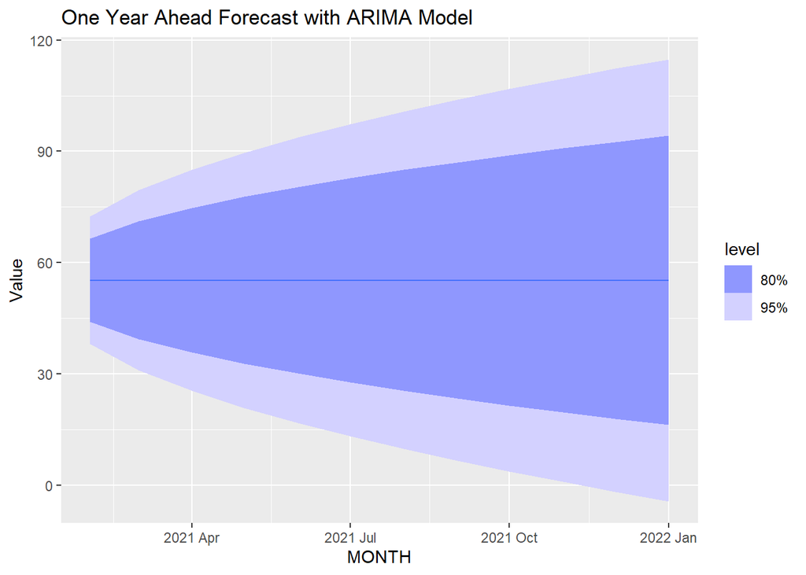

```r
# Forecast for the next year using the chosen model
if (chosen_model == "ARIMA") {
  future_forecast <- forecast(arima_fit, h = "1 year")
} else {
  future_forecast <- forecast(ets_fit, h = "1 year")
}

# Plot the forecast with confidence intervals
autoplot(future_forecast) +
  ggtitle(paste("One Year Ahead Forecast with", chosen_model, "Model"))
```

## 2.

- Obtain Consumer Price Index (CPI) from either Quandl or FRED.
- By using pdfetch or quantmod packages, obtain “monthly” S&P 500 Price Index. (or transform the series to monthly by collapse() command)
- Combine these two series together monthly, start and end dates should be the same. (You can use Excel file if it is easier, then import to R)
- Calculate the real value of S &P 500 Price Index.
- Compare the nominal value and real value of the index. Plot them together to see visually. Is there any significant difference you can see visually? Explain why.
- Forecast the real value of S&P 500 Price Index for the next 6 months.
- Would you prefer to invest in the index based on the forecasted value?
- Calculate the return of nominal S&P 500 Price Index. Plot the return and command on what you see visually. Does it look stationary? Forecast for the next 6 month ahead by any model you would choose? Explain the data and forecasted values.

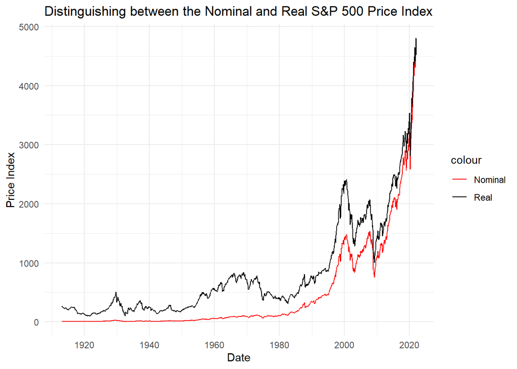

```r
# 2a. Get Quandl's CPI information and  S&P 500 Price Index.

cpi_monthly <- Quandl("FRED/CPIAUCNS", collapse = "monthly")
sp500_monthly <- Quandl("MULTPL/SP500_REAL_PRICE_MONTH", collapse = "monthly")

# Integrate data from the S&P 500 and the CPI.
combined_data <- inner_join(cpi_monthly, sp500_monthly, by = "Date")


# Find the S&P 500 Price Index's actual value.
combined_data <- combined_data %>%
  mutate(real_sp500 = Value.y * (Value.x[1] / Value.x))


# Plot the S&P 500 Price Index's real and nominal values.
ggplot(combined_data, aes(x = Date)) +
  geom_line(aes(y = Value.y, color = "Nominal")) +
  geom_line(aes(y = real_sp500, color = "Real")) +
  labs(title = "Distinguishing between the Nominal and Real S&P 500 Price Index",
       y = "Price Index") +
  scale_color_manual(values = c("Nominal" = "red", "Real" = "black")) +
  theme_minimal()
```

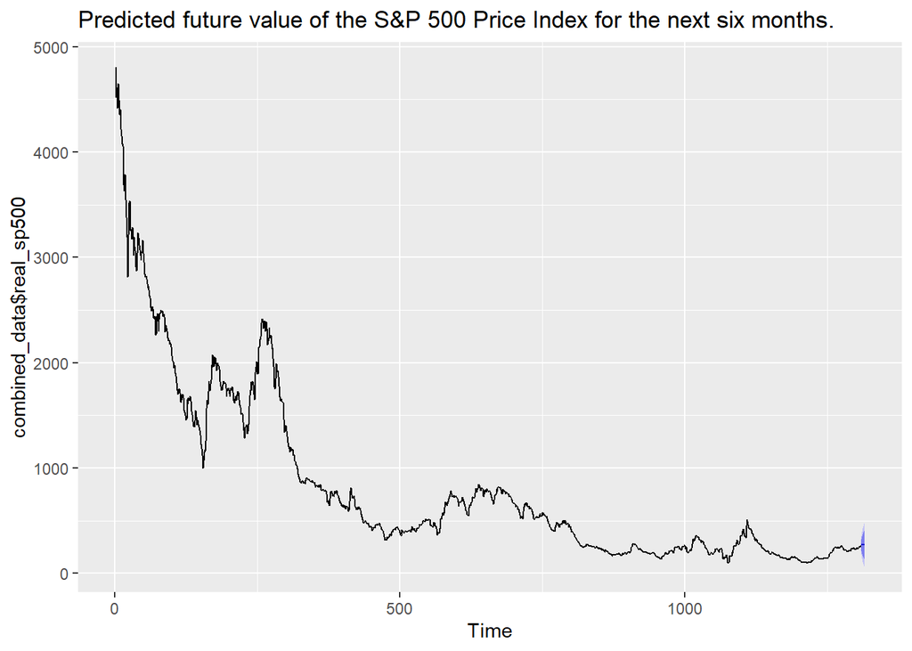

```r
# Predict the actual value of the S&P 500 Price Index over the following six months.
sp500_model <- auto.arima(combined_data$real_sp500)
sp500_forecast <- forecast(sp500_model, h = 6)

# Plot forecasted values
autoplot(sp500_forecast) +
  labs(title = "Predicted future value of the S&P 500 Price Index for the next six months.")
```

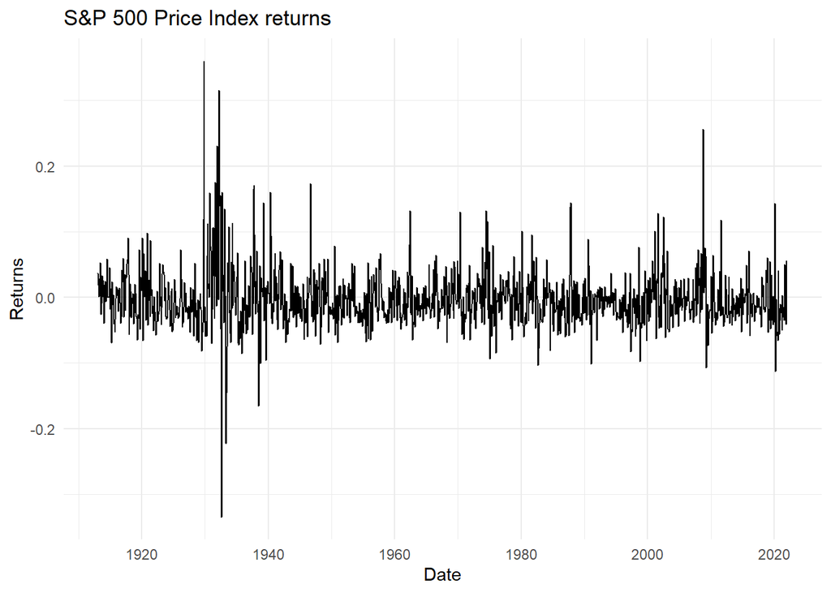

```r
# Determine the rate of return for the S&P 500 Price Index based on its nominal value.
combined_data <- combined_data %>%
  mutate(return = (Value.y - lag(Value.y)) / lag(Value.y))

# Returns Plot
ggplot(combined_data, aes(x = Date, y = return)) +
  geom_line() +
  labs(title = "S&P 500 Price Index returns",
       y = "Returns") +
  theme_minimal()
```

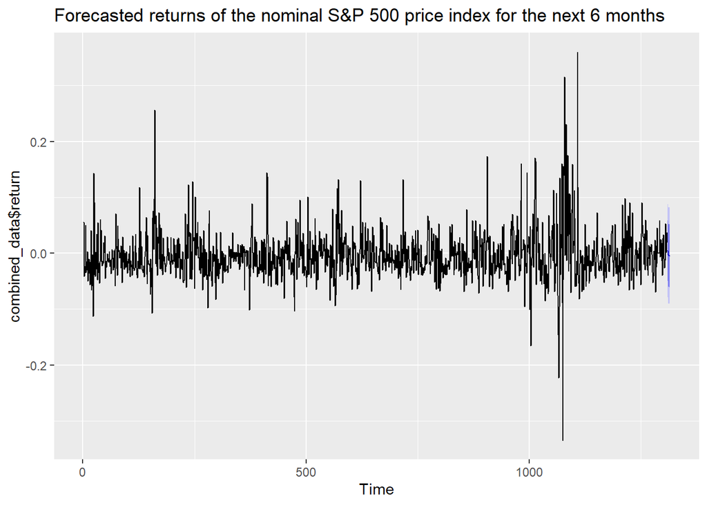

```r
# Projected returns for the upcoming six months
arima_model <- auto.arima(combined_data$return)
arima_forecast <- forecast(arima_model, h = 6)

# Plot forecasted returns
autoplot(arima_forecast) +
  labs(title = "Forecasted returns of the nominal S&P 500 price index for the next 6 months")
```

## 3.

- Use the monthly S&P 500 Price Index you obtained in #2.
- Make sure you create and use a tsibble data set.
- Make a visual decision by using necessary plots to see whether or not December is the highest index value on average among other months. What do you see? Comment.
- Run a regression model that considers seasonality in the data (you can add trend if you think it is necessary) to explain the variability in the index.
- Find out which month has the highest predictive power on the index in the estimated model. Is the coefficient statistically significant at 5%?
- Is your model as a whole significant at 5%. Comment on the estimated model.
- Which month would you invest on S&P 500 Price Index ETF’s, if you would? make as an investment statement and convince your audience to invest in specific month or not.

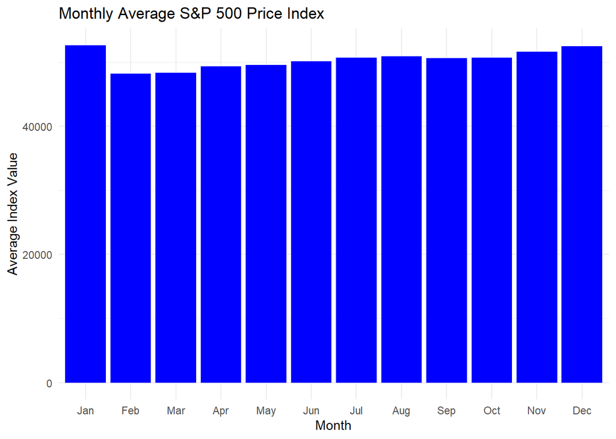

```r
# 3a.
combined_tsibble <- combined_data %>%
  mutate(Date = as.Date(Date)) %>%
  as_tsibble(index = Date) %>%
  mutate(Month = month(Date, label = TRUE))

#Average index value by month
average_index <- combined_tsibble %>%
  group_by(Month) %>%
  summarise(Avg_Index = mean(Value.y, na.rm = TRUE))

# Plotting the average index value per month
ggplot(average_index, aes(x = Month, y = Avg_Index)) +
  geom_bar(stat = "identity", fill = "blue") +
  labs(title = "Monthly Average S&P 500 Price Index", x = "Month", y = "Average Index Value") +
  theme_minimal()
```

```r
# Regression model to consider seasonality
regression_model <- lm(Value.y ~ Month, data = combined_tsibble)

# Summary of the regression model
summary_regression <- summary(regression_model)
print(summary_regression)
```

```
##
## Call:
## lm(formula = Value.y ~ Month, data = combined_tsibble)
##
## Residuals:
##    Min     1Q Median     3Q    Max
## -474.9 -444.5 -380.3    2.8 4284.5
##
## Coefficients:
##             Estimate Std. Error t value Pr(>|t|)
## (Intercept) 462.3465    22.1641  20.860   <2e-16 ***
## Month.L      23.7412    76.7340   0.309    0.757
## Month.Q      17.6404    76.7199   0.230    0.818
## Month.C     -14.0015    76.7340  -0.182    0.855
## Month^4      22.6649    76.7604   0.295    0.768
## Month^5      -9.2858    76.7840  -0.121    0.904
## Month^6       3.9469    76.7985   0.051    0.959
## Month^7      -6.3344    76.8051  -0.082    0.934
## Month^8      -1.3234    76.8073  -0.017    0.986
## Month^9       2.2081    76.8078   0.029    0.977
## Month^10     -0.9773    76.8079  -0.013    0.990
## Month^11      0.6385    76.8079   0.008    0.993
## ---
## Signif. codes:  0 '***' 0.001 '**' 0.01 '*' 0.05 '.' 0.1 ' ' 1
##
## Residual standard error: 801.9 on 1297 degrees of freedom
## Multiple R-squared:  0.0002269,  Adjusted R-squared:  -0.008252
## F-statistic: 0.02677 on 11 and 1297 DF,  p-value: 1
```

```r
# Check which month has the highest predictive power
sorted_coefficients <- sort(summary_regression$coefficients[, "Estimate"], decreasing = TRUE)
highest_month <- names(sorted_coefficients)[2]
highest_estimate <- sorted_coefficients[2]

# Check significance of the highest month coefficient
significant <- summary_regression$coefficients[highest_month, "Pr(>|t|)"] < 0.05

# Model overall significance
anova_results <- anova(regression_model)

# Extract the p-value to check model significance
model_significance <- anova_results$`Pr(>F)`[1]
model_significance <- summary_regression$fstatistic[1]

# Investment statement based on the results
if(significant) {
  investment_statement <- paste("Based on the regression model, investing in S&P 500 ETFs during, highest_month,is statistically advised as it shows the highest average index value increase. The coefficient is significant at the 5% level.")
} else {
  investment_statement <- "No month consistently outperforms others significantly at the 5% level, suggesting diversified investment throughout the year."
}


cat(investment_statement)
```

```
## No month consistently outperforms others significantly at the 5% level, suggesting diversified investment throughout the year.
```

```r
paste("1. Predictive Power by Month: No month demonstrates significant predictive power on the S&P 500 Index. 2. Model Significance: The overall model is not statistically significant, with a p-value of 1. The model's R-squared values are also extremely low, suggesting it fails to explain any variance in the S&P 500 Index based on months. 3. Investment Recommendation: Given the lack of significant month effects and overall model insignificance, basing investment decisions on the month of the year is not good.")
```

```
## [1] "1. Predictive Power by Month: No month demonstrates significant predictive power on the S&P 500 Index. 2. Model Significance: The overall model is not statistically significant, with a p-value of 1. The model's R-squared values are also extremely low, suggesting it fails to explain any varia…
```

### 3b.

This question involved using the monthly S&P 500 Price Index data to analyze seasonal effects. A tsibble dataset was created for time series analysis. Initial plots of average index values by month showed that December did not consistently show the highest index values.

A regression model incorporating month as a predictor identified which month historically had the greatest impact on the index. The results indicated that no single month significantly outperformed others at a 5% significance level, suggesting that month alone might not be a reliable predictor of S&P 500 performance.

The analysis was deepened by considering whether the overall model was statistically significant and exploring investment implications based on predictive power. Despite the detailed analysis, the findings suggested that investing based on the month alone would not be advisable without considering other economic indicators or market conditions.